# Triagem de Arquivos de Imagem

Prof. Cesar Henrique Comin

## Triagem de imagens

- Um conjunto de imagens é **uma pasta com arquivos**. Não há um esquema para validação (colunas numéricas, categorias, etc.).
- Erros em imagens raramente são revelados naturalmente. Uma imagem em branco pode ser usada no treinamento de um modelo de AM sem problemas.
- **Triagem** é tudo que dá para descobrir sobre o conjunto usando apenas os arquivos e os pixels, sem modelo nenhum.

## As três perguntas

1. **O que é cada arquivo?** Formato, modo de cor, profundidade de bits, metadados.
2. **Que forma ele tem?** Resolução, proporção, e o que o redimensionamento vai fazer com ela.
3. **Há repetição?** Cópias exatas, cópias recodificadas, e versões parecidas da mesma foto.

# Checagens de arquivos

## Extensão não é formato

- A extensão é parte do **nome**. O formato de verdade está nos primeiros bytes do arquivo, e é assim que qualquer biblioteca decide como ler.
- `.jpg`, `.jpeg`, `.JPG` e `.JPEG` são quatro nomes para o mesmo formato.
- Um `glob("*.jpeg")` no conjunto `pvd_images` devolve 1487 dos 1845 arquivos.
- **Maiúscula é problema do sistema de arquivos.** No Linux, `.jpg` é diferente de `.JPG`. No Windows, não.

## Formatos que aparecem na prática

| Formato | Perda | Alfa | Observação |
| --- | --- | --- | --- |
| JPEG | sim | não | O mais comum. Recomprimir degrada cada vez mais |
| PNG | não | sim | Preserva os pixels. Ideal para imagens simples |
| WebP | opcional | sim | Cada vez mais comum em imagens da web |
| AVIF, HEIC | sim | sim | Padrão de celular recente. Exige biblioteca extra para ler |
| TIFF | opcional | sim | Científico e de digitalização. Aceita 16 bits e várias páginas |
| GIF | não | binário | Possivelmente várias imagens no mesmo arquivo |

## Modos de cor

| Modo | O que é | O que `np.asarray(image)` retorna |
| --- | --- | --- |
| `RGB` | três canais de cor | `(altura, largura, 3)` de `uint8` |
| `L` | um canal de cinza | `(altura, largura)`, sem o eixo de canal |
| `RGBA` | cor mais transparência | `(altura, largura, 4)` de `uint8` |
| `P` | paleta indexada | `(altura, largura)` de **índices**, e não de cores |
| `CMYK` | quatro cores para impressão | `(altura, largura, 4)` de `uint8` |
| `1` | um bit por pixel | `(altura, largura)` de `bool` |

- Uma função que faça `array[:, :, 0]` para extrair o canal vermelho vai falhar em `L` e `1`, e vai devolver **índices** em `P`.

## Profundidade de bits e cinza disfarçado

- O padrão é **8 bits por canal**, com valores de 0 a 255. Existem também PNG e TIFF de 16 bits, em que os valores vão até 65535.
- Há ainda o caso que nenhum metadado revela: uma imagem com os três canais iguais é **nível de cinza disfarçado de RGB**.
  - Só se descobre comparando os canais entre si.

## Metadados

- Arquivos de imagens possuem metadados com informações sobre a câmera, data, GPS, etc.
- A tag **EXIF `Orientation`** armazena a rotação que deve ser aplicada na imagem para que ela seja exibida corretamente.

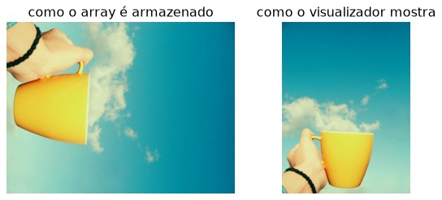

# Tamanhos de imagens

## Resolução e proporção

- É comum que imagens sejam redimensionadas para um tamanho fixo antes de serem usadas em um modelo de AM.
- O redimensionamento pode provocar perda de informação, arquivos maiores do que o necessário, e distorção da geometria.
- O primeiro passo é **entender a distribuição de resoluções e proporções** no conjunto.

## Largura x altura e proporção

- altura x largura e proporção das imagens do dataset `pvd_images`:

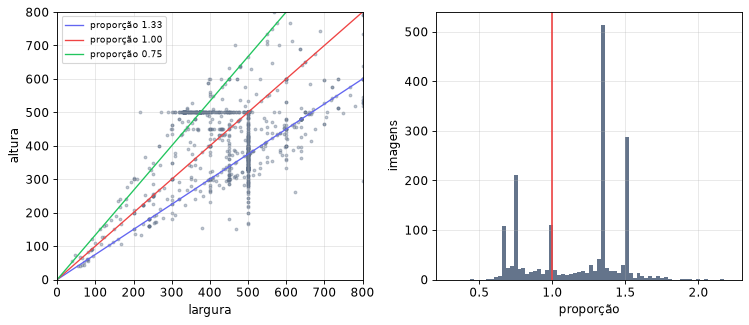

## O que distorce a geometria

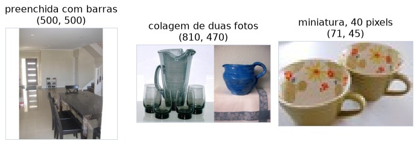

- Barras de preenchimento entram no cálculo de estatísticas de pixel e puxam a média para o preto ou para o branco.
- Colagens trazem dois assuntos no mesmo arquivo, e um rótulo só.
- Miniaturas de 40 pixels esticadas até 224 viram um borrão.

# Detecção de imagens duplicadas

## Imagens duplicadas

- O que é uma duplicata? Duas imagens são duplicatas se **são a mesma foto**, mesmo que tenham sido recodificadas, redimensionadas, recortadas ou clareadas.
- Dois tipos:
  - **duplicata exata:** mesmo arquivo, com os mesmos bytes
  - **quase-duplicata:** mesma foto, mas com pixels diferentes

## Por que duplicata importa

1. **Vazamento entre treino e teste:** Imagens duplicadas podem aparecer em ambos os conjuntos, e o modelo aprende a memorizar em vez de generalizar.
2. **Peso dobrado:** Uma imagem presente cinco vezes conta cinco vezes no ajuste do modelo.
3. **Rótulo em conflito:** Duas cópias da mesma foto com rótulos diferentes indicam que pelo menos uma das duas está errada.

## Duplicata exata

- Nome e tamanho em disco não são confiáveis. Um arquivo pode ser renomeado ou recodificado sem mudar a foto.
- O padrão é comparar o **conteúdo** com um hash criptográfico como `md5` ou `sha256`. Ele resume o arquivo inteiro num código curto, e códigos iguais significam bytes iguais.

## Exemplo de hash criptográfico

- Duas strings com um único caractere diferente produzem códigos completamente diferentes:

```python
for text in ["Processamento de dados", "Processamento de dadoS"]:
    print(text, hashlib.md5(text.encode()).hexdigest())
```

```
Processamento de dados b92b23e65ec71bd2e5afd5c908adb129
Processamento de dadoS 7aa1058a0a209e898da2226abb7b192d
```

- O hash não diz **quão diferentes** são as entradas, apenas se são idênticas ou não.

## Hash criptográfico: duplicatas no `pvd_images`

- Alguns arquivos no `pvd_images` são cópias exatas:

```
8gvzi.jpeg 13c14fca85f9b4e2c5136bd176b98ddb
k1j6f.jpeg 13c14fca85f9b4e2c5136bd176b98ddb
svz2e.jpeg 40c118c8f4678361349f58756da1adf6
u82pi.jpeg 40c118c8f4678361349f58756da1adf6
hju1g.jpeg 5602fa784a28ac50edbf5ca188ce01ae
yeawh.jpeg 5602fa784a28ac50edbf5ca188ce01ae
```

## Quase-duplicata

- Duplicata exata não funciona para imagens recodificadas, redimensionadas, recortadas ou clareadas. O `md5` não vê relação nenhuma entre elas.

[figure not shown]

## Hash perceptual

- Queremos um resumo curto com a propriedade **oposta** à do `md5`. No `md5`, trocar um bit da entrada muda o código inteiro.
- Um **hash perceptual** precisa possuir três propriedades:
  1. Ser insensível ao que não muda o conteúdo, como recomprimir, redimensionar e clarear
  2. Ser sensível ao que muda o conteúdo
  3. Permitir comparar dois códigos por uma distância barata
- A distância usada é a de **Hamming**, que conta em quantos bits os dois códigos diferem.

## aHash

[figure not shown]

- O **aHash** é o hash perceptual mais simples. Converte para cinza, reduz o tamanho para 8 por 8, e compara cada um dos 64 valores com a média. A imagem se torna uma sequência de 64 bits.
- Cada 4 bits são transformados em um dígito hexadecimal, e o hash final é uma string de 16 caracteres.

## pHash e MarrHildrethHash

- O **pHash** analisa o quanto a imagem varia devagar em cada direção, e variação lenta é justamente o que sobrevive a recompressão, redimensionamento e mudança de brilho.
- O **MarrHildrethHash** detecta as bordas na imagem e utiliza essa informação para produzir 576 bits.

## Comparando hashes

- A distância de Hamming entre dois hashes é o número de bits diferentes entre eles.
- É preciso calcular a distância entre todos os pares de imagens, e decidir um **limiar** para considerar duas imagens como quase-duplicatas.
- A escolha do limiar depende do hash usado, e da tolerância a falsos positivos e falsos negativos.

## Limites do hash perceptual

- Variações extremas dos pixels da imagem inviabilizam o hash perceptual:

[figure not shown]

- Identificar duplicatas **semânticas** requer o uso de redes neurais.

## Roteiro de triagem

1. Listar os arquivos sem confiar na extensão, comparando o sufixo em minúsculas.
2. Montar uma tabela de inventário com formato, modo, dimensões e hash, dentro de um `try`.
3. Olhar as contagens por formato e por modo, e abrir um exemplo de cada caso raro.
4. Escrever uma função de leitura que devolva sempre a mesma coisa, e registrar o que ela decide descartar.
5. Olhar a distribuição de resolução e de proporção antes de escolher o redimensionamento.
6. Agrupar duplicatas exatas pelo hash dos bytes, e quase-duplicatas pelo hash perceptual.

## Assuntos adicionais

- Existem outras famílias de hash perceptual, como o `dHash`, que compara pixels vizinhos, e o `BlockMeanHash`. Todas trocam precisão por revocação utilizando diferentes estratégias.
- Em conjuntos com milhões de imagens, comparar todos os pares deixa de ser viável e a busca passa a usar índices por vizinhança aproximada.
- Bibliotecas como `imagededup` e `FiftyOne` são populares para detecção de duplicatas.